# Camera Trap Analysis

Marc Los Huertos

EA030 · Compiled 2026-04-08

EA030 — RTricks — Project 05

# Camera Trap Analysis: Wildlife Detection and Behavior

**Prof. Marc Los Huertos** • Pomona College • Environmental Analysis

← Back to Index

Introduction Setup Import & Clean Detection Events Descriptive Behavior × Diel Activity Overlap Diversity Occupancy Summary

> **What this project covers.** Camera traps record *who* was present, *when*, and *what they were doing* without a researcher present. This tutorial walks the complete analytical pipeline — from raw Excel export through cleaning, independent-event definition, descriptive ethograms, and four quantitative methods: chi-square/Fisher tests of diel behavior shifts, kernel-density activity overlap, rarefaction-corrected diversity, and single-season occupancy modeling.

## The Analytical Pipeline

Camera-trap data require several decisions before any statistics can be run. The diagram below maps the full workflow covered in this project.

Stage 1

Import & Clean

Read Excel, standardize columns, remove ambiguous taxa, collapse behavior codes.

Stage 2

Independent Events

Apply the 30-minute rule to collapse burst detections into single events. Prevents pseudo-replication.

Stage 3

Descriptive Stats

Ethogram, hourly heat map, camera-level activity profiles.

Stage 4

Hypothesis Testing

Chi-square / Fisher: does behavior composition differ between day and night?

Stage 5

Activity Overlap

Kernel-density overlap coefficient Δ quantifies temporal co-occurrence between species pairs.

Stage 6

Occupancy Model

MacKenzie et al. (2002) separates true absence from non-detection to estimate ψ and p.

**🆕 New to R?** Don’t worry if every line of code is not immediately clear. Each section explains *what* the code does and *why* before showing how to run it. Focus on understanding the logic; the syntax will become familiar with practice. Sections marked with ⚙️ go deeper into the statistical machinery — they are optional on a first reading.

## 1. Setup

### Packages

R’s base functionality is extended by **packages** — collections of functions written by the community. Install each package once with `install.packages()`, then load it every session with `library()`.

```r
# Run the install lines once — remove the # to uncomment:
# install.packages(c("tidyverse", "lubridate", "janitor", "readxl",
#                    "vegan", "overlap", "unmarked", "RColorBrewer"))

library(tidyverse)   # data wrangling + ggplot2
library(lubridate)   # date-time helpers
library(janitor)     # clean_names() standardises column headers
library(readxl)      # read Excel files
library(vegan)       # diversity indices and rarefaction
library(overlap)     # kernel-density activity-overlap (Ridout & Linkie 2009)
library(unmarked)    # occupancy models (MacKenzie et al. 2002)
```

**⚙️ Why these packages?**  
`tidyverse` — a suite of packages sharing a consistent grammar for data manipulation (`dplyr`, `tidyr`) and visualisation (`ggplot2`).  
`overlap` — implements the Δ estimator of Ridout & Linkie (2009) for circular (time-of-day) kernel densities.  
`unmarked` — fits hierarchical models that separate ecological state (occupancy) from the observation process (detection probability).

## 2. Data Import and Cleaning

### Step 1 Load the data

`read_excel()` reads a named sheet from an `.xlsx` file into a **data frame** — R’s standard rectangular data structure (rows = observations, columns = variables). Update `file_path` to match your own file location.

```r
file_path <- "/home/mwl04747/RTricks/15_Camera_Traps/Camera Trap Data Entry.xlsx"

cam_raw <- read_excel(path = file_path, sheet = "Combined")

glimpse(cam_raw)
```

```
## Rows: 1,197
## Columns: 6
## $ Camera_ID                                 <chr> "P70-03", "P70-03", "P70-03"…
## $ `DateTimeStamp (YYYY-MM-DD HH:MM:SS PST)` <chr> "46093.241377314815", "46093…
## $ Datetime_corrected                        <dttm> 2026-03-12 05:47:35, 2026-0…
## $ Taxa_code                                 <chr> "C_latrans", "C_latrans", "C…
## $ Behavior_code                             <chr> "walk", "hop", "walk", "snif…
## $ Notes                                     <chr> NA, NA, "exiting burrow", NA…
```

**💡 `glimpse()` is your first-look friend.** It shows every column name, its data type (`<chr>` = text, `<dbl>` = number, `<dttm>` = date-time), and the first few values — far more useful than `head()` for wide data frames.

### Step 2 Standardize column names and parse dates

Column names from Excel often contain spaces and mixed capitalisation. `clean_names()` converts them to `snake_case` (lower case, underscores instead of spaces) so they are easier to type and less error-prone.

```r
cam_raw$datetime <- cam_raw$Datetime_corrected

cam <- cam_raw %>%
  clean_names() %>%
  mutate(
    date = as.Date(datetime),   # strip the time component; keep date only
    hour = hour(datetime)       # extract hour of day as integer (0–23)
  )

summary(cam$date)
```

```
##         Min.      1st Qu.       Median         Mean      3rd Qu.         Max.
## "2026-03-09" "2026-03-12" "2026-03-15" "2026-03-15" "2026-03-18" "2026-03-23"
##         NA's
##          "1"
```

### Step 3 Remove ambiguous taxa

Some records contain notes like `"bird"`, `"unknown"`, or combined entries (`"squirrel/rat"`). These are genuinely unidentifiable and must be excluded before analysis — their presence would inflate richness estimates and contaminate behavior summaries.

```r
ambiguous_patterns <- c(
  " and ", " or ", "/",
  "unknown", "unidentified", "n/a", "^na$",
  "bird$", "small brown bird"
)

cam_clean <- cam %>%
  filter(
    !str_detect(
      str_to_lower(taxa_code),
      paste(ambiguous_patterns, collapse = "|")
    )
  )

cat("Taxa retained after filtering:\n")
```

```
## Taxa retained after filtering:
```

```r
unique(cam_clean$taxa_code)
```

```
##  [1] "C_latrans"             "A_californica"         "O_beecheyi"
##  [4] "S_bachmani"            "M_crissalis"           "C_cristata"
##  [7] "S_niger"               "D_virginiana"          "M_musculus"
## [10] "Black-headed Grosbeak" "R_norvegicus"          "M_mephitis"
```

**📌 Regular expressions**

`str_detect()` matches text against a **pattern**. `paste(…, collapse = “|”)` joins our list of ambiguous strings with the “or” operator (`|`), so one call checks all of them simultaneously. The `!` at the front keeps only rows that do *not* match any ambiguous pattern.

### Step 4 Collapse behaviors into functional types

Raw behavior codes (`"walk"`, `"run"`, `"hop"`) are too granular for most analyses. `case_when()` groups them into five **functional categories** — think of it as a multi-way if/else evaluated in order.

```r
cam <- cam_clean %>%
  mutate(
    behavior_function = case_when(
      str_detect(behavior_code, "walk|run|hop|fly|climb|crawl") ~ "movement",
      str_detect(behavior_code, "eat|dig|cache")                ~ "foraging",
      str_detect(behavior_code, "sniff")                        ~ "investigation",
      str_detect(behavior_code, "stare")                        ~ "vigilance",
      str_detect(behavior_code, "stop|stand|sit|lay")           ~ "stationary",
      TRUE                                                      ~ "other"
    )
  )

table(cam$behavior_function)
```

```
##
##      foraging investigation      movement         other    stationary
##           106            76           754            43           101
##     vigilance
##            67
```

## 3. Defining Independent Detection Events

### The pseudo-replication problem

A single animal may trigger the same camera dozens of times over a few minutes. Treating each trigger as an independent observation would **pseudo-replicate** the data — inflating sample sizes and biasing every statistic downstream.

### The 30-minute rule

The standard solution: any detections of the **same species at the same camera** within 30 minutes of the previous detection are treated as part of the *same* event. Only a detection after a ≥ 30-minute gap counts as a new independent event.

```r
cam_events <- cam %>%
  arrange(camera_id, taxa_code, datetime) %>%
  group_by(camera_id, taxa_code) %>%
  mutate(
    # Time gap in minutes between consecutive rows within each camera × species group
    minutes_since_last = as.numeric(
      difftime(datetime, lag(datetime), units = "mins")
    ),
    # A new event begins if gap > 30 min OR this is the very first record
    new_event = if_else(
      is.na(minutes_since_last) | minutes_since_last > 30, 1L, 0L
    ),
    # Cumulative sum gives a running event counter within each group
    event_id = cumsum(new_event)
  ) %>%
  ungroup() %>%
  mutate(diel = if_else(hour >= 6 & hour < 18, "day", "night"))

# How many independent events per species?
cam_events %>%
  distinct(camera_id, taxa_code, event_id) %>%
  count(taxa_code, name = "independent_events") %>%
  arrange(desc(independent_events))
```

```
## # A tibble: 12 × 2
##    taxa_code             independent_events
##    <chr>                              <int>
##  1 O_beecheyi                           179
##  2 S_bachmani                           141
##  3 C_latrans                            126
##  4 M_crissalis                           32
##  5 S_niger                               31
##  6 A_californica                         21
##  7 M_musculus                            15
##  8 C_cristata                             3
##  9 Black-headed Grosbeak                  1
## 10 D_virginiana                           1
## 11 M_mephitis                             1
## 12 R_norvegicus                           1
```

**📌 Why `lag()` is the right tool here**

`lag(datetime)` returns the value from the *previous row*. Because we first `group_by(camera_id, taxa_code)`, “previous” means the last detection of that species at that specific camera — exactly what we need to measure within-burst gaps. Without grouping, `lag()` would compare across species and cameras, giving meaningless gaps.

**⚠️ Choosing a time threshold**

30 minutes is a widely used convention, but the right threshold depends on your study organism’s typical bout length and movement speed. For a chipmunk foraging in a small area, 30 minutes may be too long. For a wide-ranging carnivore like a mountain lion, 60–120 minutes may be more appropriate. Whatever threshold you choose, document it clearly in your methods.

## 4. Descriptive Statistics

### 4.1 Detection event totals per taxon

```r
event_summary <- cam_events %>%
  distinct(camera_id, taxa_code, event_id) %>%
  count(taxa_code, name = "detection_events") %>%
  arrange(desc(detection_events))

print(event_summary)
```

```
## # A tibble: 12 × 2
##    taxa_code             detection_events
##    <chr>                            <int>
##  1 O_beecheyi                         179
##  2 S_bachmani                         141
##  3 C_latrans                          126
##  4 M_crissalis                         32
##  5 S_niger                             31
##  6 A_californica                       21
##  7 M_musculus                          15
##  8 C_cristata                           3
##  9 Black-headed Grosbeak                1
## 10 D_virginiana                         1
## 11 M_mephitis                           1
## 12 R_norvegicus                         1
```

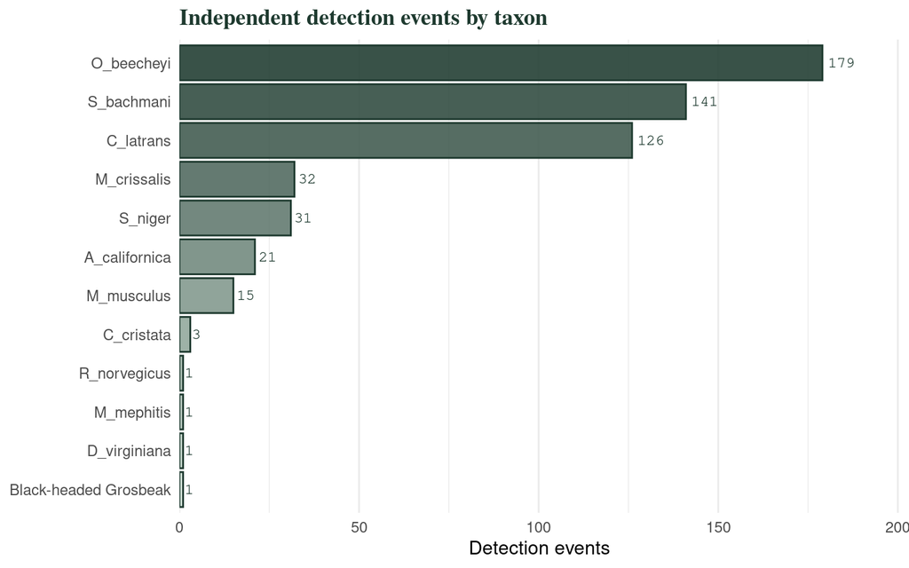

```r
ggplot(event_summary,
       aes(x = reorder(taxa_code, detection_events),
           y = detection_events,
           fill = reorder(taxa_code, detection_events))) +
  geom_col(color = "#1e3a2f", alpha = 0.88) +
  geom_text(aes(label = detection_events), hjust = -0.2,
            family = "mono", size = 3.4, color = "#1e3a2f") +
  coord_flip() +
  scale_fill_manual(
    values = colorRampPalette(c("#d4e6da", "#1e3a2f"))(nrow(event_summary))
  ) +
  scale_y_continuous(expand = expansion(mult = c(0, 0.12))) +
  labs(title = "Independent detection events by taxon",
       x = NULL, y = "Detection events") +
  theme_minimal(base_size = 12) +
  theme(
    plot.title      = element_text(family = "serif", face = "bold", color = "#1e3a2f"),
    legend.position = "none",
    panel.grid.major.y = element_blank()
  )
```

### 4.2 Behavioral ethogram (stacked bar)

An **ethogram** documents the relative frequency of each behavior. Proportional bars enable cross-species comparison even when total event counts differ substantially between species.

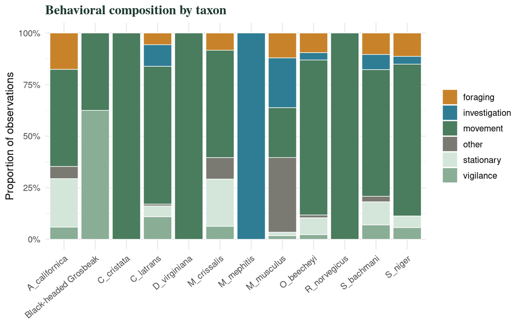

```r
ethogram <- cam_events %>%
  count(taxa_code, behavior_function) %>%
  group_by(taxa_code) %>%
  mutate(prop = n / sum(n)) %>%
  ungroup()

ggplot(ethogram, aes(x = taxa_code, y = prop, fill = behavior_function)) +
  geom_col(color = "white", linewidth = 0.3) +
  scale_fill_manual(
    values = c(
      "movement"      = "#4a7c5e",
      "foraging"      = "#c8832a",
      "investigation" = "#2e7d94",
      "vigilance"     = "#8aad96",
      "stationary"    = "#d4e6da",
      "other"         = "#7a7a72"
    )
  ) +
  scale_y_continuous(labels = scales::percent_format()) +
  theme_minimal(base_size = 12) +
  theme(
    plot.title   = element_text(family = "serif", face = "bold", color = "#1e3a2f"),
    axis.text.x  = element_text(angle = 40, hjust = 1),
    legend.title = element_blank()
  ) +
  labs(title = "Behavioral composition by taxon",
       x = NULL, y = "Proportion of observations")
```

### 4.3 Hourly activity heat map

A **heat map** encodes counts as color intensity. Each cell is a taxon × hour combination — a fast way to spot nocturnal, diurnal, or crepuscular patterns across all taxa simultaneously.

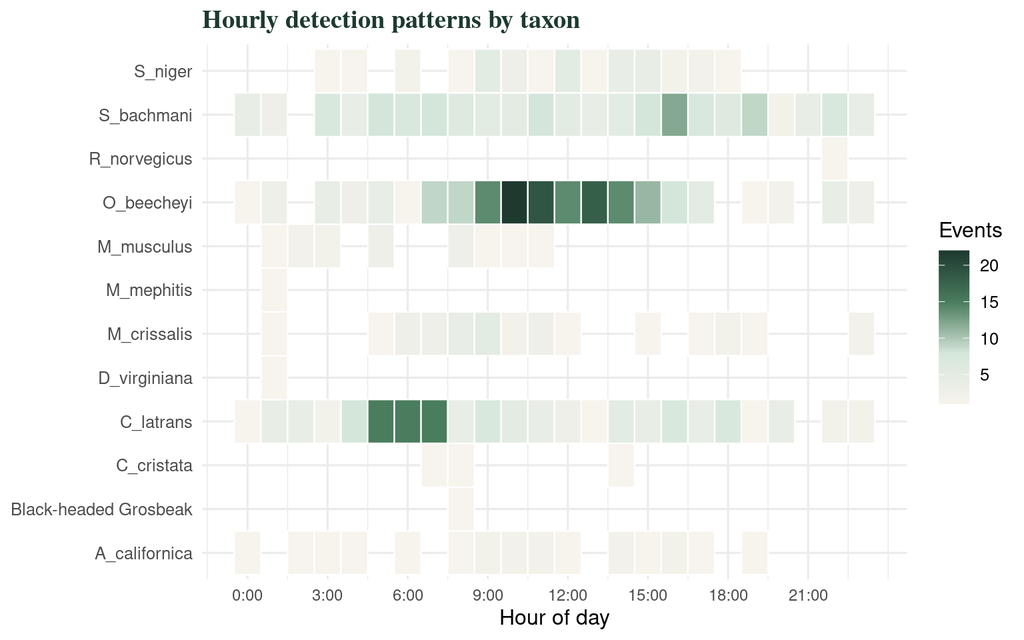

```r
taxon_hour <- cam_events %>%
  distinct(taxa_code, event_id, hour) %>%
  count(taxa_code, hour, name = "events")

ggplot(taxon_hour, aes(x = hour, y = taxa_code, fill = events)) +
  geom_tile(color = "white", linewidth = 0.4) +
  scale_fill_gradientn(
    colors = c(var_cream = "#f7f3ed", "#d4e6da", "#4a7c5e", "#1e3a2f"),
    name    = "Events"
  ) +
  scale_x_continuous(breaks = seq(0, 23, 3),
                     labels = paste0(seq(0, 23, 3), ":00")) +
  labs(title = "Hourly detection patterns by taxon",
       x = "Hour of day", y = NULL) +
  theme_minimal(base_size = 12) +
  theme(
    plot.title  = element_text(family = "serif", face = "bold", color = "#1e3a2f"),
    axis.text.x = element_text(size = 9)
  )
```

### 4.4 Camera-level activity profiles

Different cameras are placed in different micro-habitats. This plot reveals whether behavioral composition varies by camera location — an early signal of habitat-driven behavior differences.

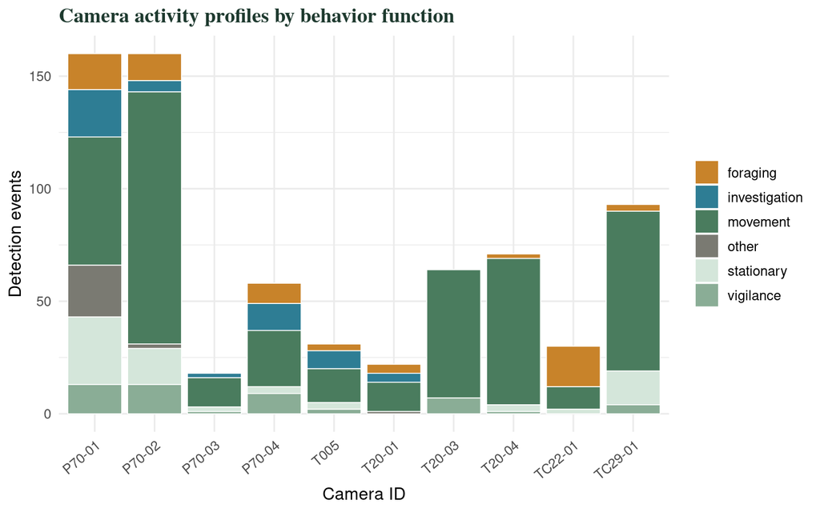

```r
camera_behavior <- cam_events %>%
  distinct(camera_id, taxa_code, event_id, behavior_function) %>%
  count(camera_id, behavior_function, name = "events")

ggplot(camera_behavior,
       aes(x = camera_id, y = events, fill = behavior_function)) +
  geom_col(color = "white", linewidth = 0.3) +
  scale_fill_manual(
    values = c(
      "movement"      = "#4a7c5e",
      "foraging"      = "#c8832a",
      "investigation" = "#2e7d94",
      "vigilance"     = "#8aad96",
      "stationary"    = "#d4e6da",
      "other"         = "#7a7a72"
    )
  ) +
  theme_minimal(base_size = 12) +
  theme(
    plot.title  = element_text(family = "serif", face = "bold", color = "#1e3a2f"),
    axis.text.x = element_text(angle = 40, hjust = 1),
    legend.title = element_blank()
  ) +
  labs(title = "Camera activity profiles by behavior function",
       x = "Camera ID", y = "Detection events")
```

## 5. Hypothesis Testing: Behavior × Diel Period

### Rationale

**Question:** Does the *proportion* of behaviors (e.g., foraging vs. vigilance) differ between day and night?

We use a **chi-square test of independence** — or Fisher’s exact test when expected cell counts are small — to test whether behavior type is statistically independent of diel period.

**H₀:** Behavior composition is the same during the day and at night.  
**H₁:** At least one behavior type is more common at one time of day.

**⚙️ Chi-square vs. Fisher’s exact test**  
The chi-square test assumes all *expected* cell counts ≥ 5. With small samples or rare behaviors, this fails. Fisher’s exact test has no such requirement — it computes an exact p-value by enumerating all possible contingency tables with the same marginal totals. Use Fisher when any expected count is below 5. The code below checks automatically.

### Run tests per taxon

```r
test_behavior_diel <- function(df) {

  # 1. Drop rows where diel is NA (records with hour == NA or bad datetime)
  df <- df %>% filter(!is.na(diel), !is.na(behavior_function))

  # 2. Guard: need observations in BOTH diel periods
  if (length(unique(df$diel)) < 2)
    return(tibble(test = "insufficient data — one diel period only",
                  stat_type = "—", statistic = NA_real_, p_value = NA_real_))

  # 3. Build the contingency table
  wide <- df %>%
    count(diel, behavior_function) %>%
    pivot_wider(names_from  = behavior_function,
                values_from = n,
                values_fill = 0)

  # 4. Guard: diel column must have no NAs before using as row names
  wide <- wide %>% filter(!is.na(diel))
  if (nrow(wide) < 2)
    return(tibble(test = "insufficient data — pivot produced < 2 rows",
                  stat_type = "—", statistic = NA_real_, p_value = NA_real_))

  tbl <- wide %>%
    column_to_rownames("diel") %>%
    as.matrix()

  # 5. Guard: need at least 2 behavior columns
  if (ncol(tbl) < 2)
    return(tibble(test = "insufficient data — fewer than 2 behavior types",
                  stat_type = "—", statistic = NA_real_, p_value = NA_real_))

  # 6. Choose chi-square vs. Fisher based on minimum expected count
  exp_counts <- suppressWarnings(chisq.test(tbl)$expected)
  if (any(exp_counts < 5)) {
    # Fisher's exact test has no single test statistic (no chi-square value).
    # For 2x2 tables it returns an odds ratio; for larger tables use NA.
    res <- fisher.test(tbl, simulate.p.value = TRUE, B = 2000)
    or_val <- if (!is.null(res$estimate)) round(as.numeric(res$estimate), 3)
              else NA_real_
    tibble(test      = "Fisher",
           statistic = or_val,      # odds ratio when 2x2; NA for larger tables
           stat_type = if (!is.na(or_val)) "odds ratio" else "—",
           p_value   = res$p.value)
  } else {
    res <- chisq.test(tbl)
    tibble(test      = "Chi-square",
           statistic = round(as.numeric(res$statistic), 3),
           stat_type = "X²",
           p_value   = res$p.value)
  }
}

behavior_tests <- cam_events %>%
  group_by(taxa_code) %>%
  group_modify(~ test_behavior_diel(.x)) %>%
  ungroup() %>%
  mutate(
    significant = ifelse(is.na(p_value), NA, p_value < 0.05),
    p_value     = round(p_value, 4)
  )

# Re-order columns for a readable table
behavior_tests <- behavior_tests %>%
  select(taxa_code, test, stat_type, statistic, p_value, significant)

knitr::kable(
  behavior_tests,
  col.names = c("Taxon", "Test used", "Statistic type",
                "Value", "p-value", "p < 0.05?"),
  caption   = paste0(
    "Diel behavior tests by taxon. ",
    "For chi-square the value is X²; ",
    "for Fisher it is the odds ratio (2×2 tables only; — for larger tables). ",
    "Fisher\'s exact test has no chi-square statistic — ",
    "NA in earlier versions was correct but misleadingly labeled."
  )
)
```

Diel behavior tests by taxon. For chi-square the value is X²; for Fisher it is the odds ratio (2×2 tables only; — for larger tables). Fisher’s exact test has no chi-square statistic — NA in earlier versions was correct but misleadingly labeled.

| Taxon | Test used | Statistic type | Value | p-value | p < 0.05? |
| --- | --- | --- | --- | --- | --- |
| A_californica | Fisher | — | NA | 0.0565 | FALSE |
| Black-headed Grosbeak | insufficient data — one diel period only | — | NA | NA | NA |
| C_cristata | insufficient data — one diel period only | — | NA | NA | NA |
| C_latrans | Fisher | — | NA | 0.3523 | FALSE |
| D_virginiana | insufficient data — one diel period only | — | NA | NA | NA |
| M_crissalis | Fisher | — | NA | 0.0240 | TRUE |
| M_mephitis | insufficient data — one diel period only | — | NA | NA | NA |
| M_musculus | Fisher | — | NA | 0.1194 | FALSE |
| O_beecheyi | Fisher | — | NA | 0.0040 | TRUE |
| R_norvegicus | insufficient data — one diel period only | — | NA | NA | NA |
| S_bachmani | Fisher | — | NA | 0.0230 | TRUE |
| S_niger | Fisher | — | NA | 0.0505 | FALSE |

### Visualize the diel behavior shift

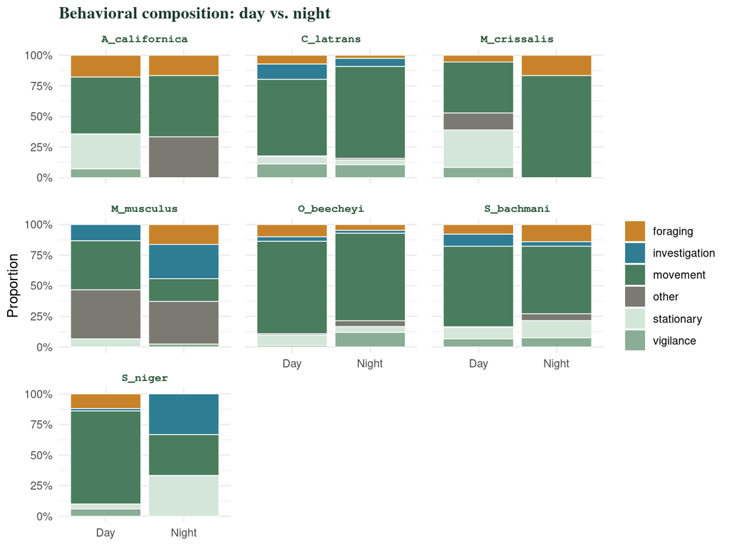

```r
behavior_diel <- cam_events %>%
  # Remove records with no diel assignment or unclassified behavior
  filter(!is.na(diel), !is.na(behavior_function)) %>%
  count(taxa_code, diel, behavior_function) %>%
  group_by(taxa_code, diel) %>%
  mutate(prop = n / sum(n)) %>%
  ungroup() %>%
  # Convert diel to a factor with clean labels so NA never appears as a panel
  mutate(
    diel = factor(diel, levels = c("day", "night"),
                  labels = c("Day", "Night"))
  )

# Only keep taxa that have observations in BOTH diel periods
both_periods <- behavior_diel %>%
  distinct(taxa_code, diel) %>%
  count(taxa_code) %>%
  filter(n == 2) %>%
  pull(taxa_code)

behavior_diel <- behavior_diel %>% filter(taxa_code %in% both_periods)

ggplot(behavior_diel,
       aes(x = diel, y = prop, fill = behavior_function)) +
  geom_col(color = "white", linewidth = 0.3) +
  facet_wrap(~ taxa_code, ncol = 3) +
  scale_fill_manual(
    values = c(
      "movement"      = "#4a7c5e",
      "foraging"      = "#c8832a",
      "investigation" = "#2e7d94",
      "vigilance"     = "#8aad96",
      "stationary"    = "#d4e6da",
      "other"         = "#7a7a72"
    )
  ) +
  scale_y_continuous(labels = scales::percent_format()) +
  labs(title = "Behavioral composition: day vs. night",
       x = NULL, y = "Proportion", fill = "Behavior") +
  theme_minimal(base_size = 11) +
  theme(
    plot.title   = element_text(family = "serif", face = "bold", color = "#1e3a2f"),
    strip.text   = element_text(family = "mono",  face = "bold", color = "#2d5a3d"),
    legend.title = element_blank(),
    panel.spacing = unit(0.8, "lines")
  )
```

**💡 Interpreting a significant test** A significant p-value tells you *that* the behavior mix differs between day and night, but not *which* behaviors drive the difference. Use the faceted stacked bars above to identify which functional types shift most. The chi-square **standardized residuals** (available in the test object as `chisq.test(tbl)$stdres`) also pinpoint which cells deviate most from independence.

## 6. Activity Overlap (Kernel Density)

### Rationale

Two species active at the same hours are more likely to interact — as competitors, predators, or prey. The **overlap coefficient Δ** (Ridout & Linkie 2009) quantifies the similarity of two diel activity curves on a 0–1 scale (0 = no temporal overlap, 1 = identical schedules).

The `overlap` package fits smooth **kernel density** curves to detection times treated as a circular variable — because 23:00 and 01:00 are only 2 hours apart, not 22.

### Why radians? Putting time on a circle

A standard 24-hour clock has an awkward edge: 23:45 and 00:15 are only 30 minutes apart in reality, but subtracting their decimal hours gives 23.5 — a huge apparent gap. The kernel density estimator would treat those two detections as nearly opposite ends of the day.

The solution is to **map the 24-hour cycle onto a circle** where midnight wraps seamlessly back to midnight. We do this by converting each detection time to **radians** (0 to 2π), the natural unit for circular data.

The conversion has three steps:

1. **Decimal hours** — combine the hour and fractional minutes into a single number: `hour + minute/60`. A detection at 14:45 becomes 14.75.
2. **Fraction of the day** — divide by 24 to get a value between 0 and 1. 14.75 / 24 = 0.615.
3. **Scale to a full circle** — multiply by 2π (≈ 6.283). 0.615 × 2π ≈ 3.86 radians.

**⚙️ The full formula**

```
time_rad = (hour +
minute/60) / 24 × 2π
```

```r
cam_events <- cam_events %>%
  mutate(
    # Step 1: decimal hours  →  Step 2: fraction of day  →  Step 3: radians
    time_rad = (hour(datetime) + minute(datetime) / 60) / 24 * 2 * pi
  )

# Sanity check: values should span 0 to ~2π (6.28)
cat(sprintf("time_rad range: %.3f to %.3f  (expected 0 to %.3f)\n",
            min(cam_events$time_rad, na.rm = TRUE),
            max(cam_events$time_rad, na.rm = TRUE),
            2 * pi))
```

```
## time_rad range: 0.105 to 6.165  (expected 0 to 6.283)
```

### Single pair: estimate Δ and bootstrap CI

```
## Activity overlap (Dhat1):  O_beecheyi vs. S_bachmani  →  Δ = 0.627
## Bootstrap 95% CI: [0.565, 0.690]
```

[figure not shown]

```r
# ── Minimum detections needed for bandwidth estimation ────────────────────────
MIN_N_OVERLAP <- 10   # raise further if bandwidth errors persist

# Helper: attempt overlap analysis, return NULL gracefully on failure
run_overlap <- function(ta, tb, sp1, sp2) {
  if (length(ta) < MIN_N_OVERLAP || length(tb) < MIN_N_OVERLAP) {
    message(sprintf("Skipping %s vs %s: too few detections (%d, %d).",
                    sp1, sp2, length(ta), length(tb)))
    return(NULL)
  }
  if (length(unique(ta)) < 5 || length(unique(tb)) < 5) {
    message(sprintf("Skipping %s vs %s: too few unique time values.", sp1, sp2))
    return(NULL)
  }
  estimator <- if (min(length(ta), length(tb)) < 75) "Dhat4" else "Dhat1"
  tryCatch({
    delta_val <- overlapEst(ta, tb, type = estimator)[estimator]
    set.seed(42)
    bs_val <- bootstrap(ta, tb, nb = 999, type = estimator)
    ci_val <- bootCI(delta_val, bs_val)
    list(estimator = estimator, delta = delta_val,
         ci_lower  = ci_val["norm0", "lower"],
         ci_upper  = ci_val["norm0", "upper"])
  }, error = function(e) {
    message(sprintf("Overlap failed for %s vs %s: %s", sp1, sp2, conditionMessage(e)))
    NULL
  })
}

# ── Pick the two species with the most independent detections ─────────────────
top2 <- cam_events %>%
  distinct(taxa_code, event_id) %>%
  count(taxa_code, sort = TRUE) %>%
  slice_head(n = 2) %>%
  pull(taxa_code)

sp1_code <- top2[1]
sp2_code <- top2[2]

t1 <- cam_events %>% filter(taxa_code == sp1_code) %>% pull(time_rad)
t2 <- cam_events %>% filter(taxa_code == sp2_code) %>% pull(time_rad)

ov <- run_overlap(t1, t2, sp1_code, sp2_code)

if (!is.null(ov)) {
  cat(sprintf("Activity overlap (%s):  %s vs. %s  \u2192  \u0394 = %.3f\n",
              ov$estimator, sp1_code, sp2_code, ov$delta))
  cat(sprintf("Bootstrap 95%% CI: [%.3f, %.3f]\n", ov$ci_lower, ov$ci_upper))
  overlapPlot(
    t1, t2,
    rug        = TRUE,
    main       = paste("Activity overlap:", sp1_code, "vs.", sp2_code),
    xlab       = "Time of day",
    linecol    = "#4a7c5e",
    linecol2   = "#c8832a",
    linewidth  = 2,
    linewidth2 = 2
  )
  legend("topright", legend = c(sp1_code, sp2_code),
         col = c("#4a7c5e", "#c8832a"), lwd = 2, bty = "n")
} else {
  # Fallback: plain hourly histograms when KDE cannot run
  par(mfrow = c(1, 2), mar = c(4, 4, 3, 1))
  hist(t1 / (2*pi) * 24, breaks = 24, col = adjustcolor("#4a7c5e", 0.7),
       border = "white", xlab = "Hour of day", main = sp1_code, xlim = c(0,24))
  hist(t2 / (2*pi) * 24, breaks = 24, col = adjustcolor("#c8832a", 0.7),
       border = "white", xlab = "Hour of day", main = sp2_code, xlim = c(0,24))
  par(mfrow = c(1, 1))
  message("KDE overlap unavailable — showing hourly histograms instead.")
}
```

**📌 Interpreting Δ**

Δ > 0.75 = high overlap; 0.50–0.75 = moderate; < 0.50 = low. If the bootstrap CI excludes a reference value of interest (e.g., Δ = 0.5), the difference is statistically supported. See Ridout & Linkie (2009) for formal guidance on estimator choice and CI interpretation.

### All pairwise overlaps (heat map)

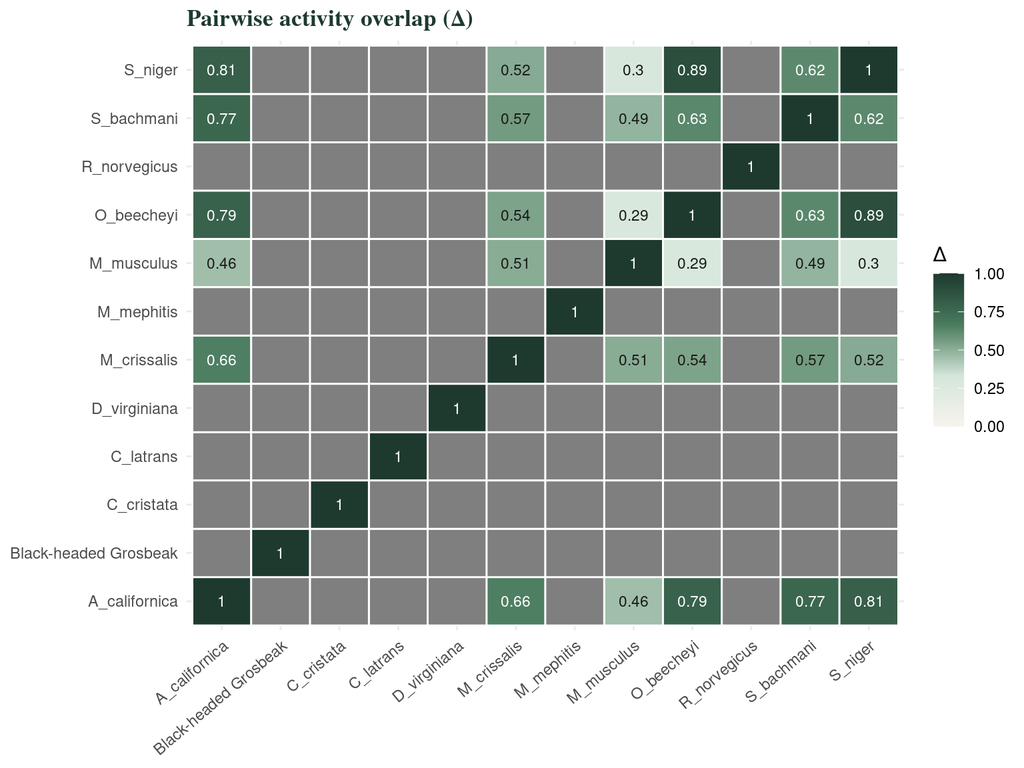

```r
taxa_list <- unique(cam_events$taxa_code)
n_sp      <- length(taxa_list)

time_by_sp <- setNames(
  lapply(taxa_list, function(sp)
    cam_events %>% filter(taxa_code == sp) %>% pull(time_rad)),
  taxa_list
)

# Helper: safe single-pair overlap (returns NA on any failure)
safe_overlap <- function(ta, tb) {
  if (length(ta) < MIN_N_OVERLAP || length(tb) < MIN_N_OVERLAP) return(NA_real_)
  if (length(unique(ta)) < 5    || length(unique(tb)) < 5)    return(NA_real_)
  est <- if (min(length(ta), length(tb)) < 75) "Dhat4" else "Dhat1"
  tryCatch(
    overlapEst(ta, tb, type = est)[est],
    error = function(e) NA_real_
  )
}

# Fill the symmetric overlap matrix, computing each pair only once
overlap_mat <- matrix(NA, n_sp, n_sp,
                      dimnames = list(taxa_list, taxa_list))
for (i in seq_len(n_sp)) {
  for (j in seq_len(n_sp)) {
    if (i == j) {
      overlap_mat[i, j] <- 1
    } else if (!is.na(overlap_mat[j, i])) {
      overlap_mat[i, j] <- overlap_mat[j, i]   # mirror already computed
    } else {
      overlap_mat[i, j] <- safe_overlap(time_by_sp[[i]], time_by_sp[[j]])
    }
  }
}

overlap_df <- as.data.frame(overlap_mat) %>%
  rownames_to_column("sp1") %>%
  pivot_longer(-sp1, names_to = "sp2", values_to = "delta")

ggplot(overlap_df, aes(x = sp1, y = sp2, fill = delta)) +
  geom_tile(color = "white", linewidth = 0.5) +
  geom_text(aes(label = round(delta, 2)), size = 3,
            color = ifelse(overlap_df$delta > 0.6, "white", "#1a1a18")) +
  scale_fill_gradientn(
    colors = c("#f7f3ed", "#d4e6da", "#4a7c5e", "#1e3a2f"),
    limits  = c(0, 1), name = "Δ"
  ) +
  labs(title = "Pairwise activity overlap (Δ)", x = NULL, y = NULL) +
  theme_minimal(base_size = 11) +
  theme(
    plot.title  = element_text(family = "serif", face = "bold", color = "#1e3a2f"),
    axis.text.x = element_text(angle = 40, hjust = 1)
  )
```

## 7. Species Diversity and Rarefaction

### Rationale

Some cameras may be in richer habitats and detect more species. But cameras also vary in **effort** — a busier camera accumulates more detections by chance, inflating apparent diversity. **Rarefaction** corrects for this by asking: *how many species would we expect if all cameras had the same total event count?*

### Build the site × species matrix

```r
# One row per camera, one column per taxon, cell = independent event count
site_sp <- cam_events %>%
  distinct(camera_id, taxa_code, event_id) %>%
  count(camera_id, taxa_code, name = "events") %>%
  pivot_wider(names_from  = taxa_code,
              values_from = events,
              values_fill = 0) %>%
  column_to_rownames("camera_id")

print(site_sp)
```

```
##         A_californica Black-headed Grosbeak C_latrans M_crissalis M_musculus
## P70-01              8                     1         3          18         14
## P70-02              1                     0        17          11          0
## P70-03              5                     0         7           0          0
## P70-04              0                     0        38           0          0
## T005                2                     0         7           0          0
## T20-01              0                     0         0           0          0
## T20-03              0                     0        27           2          0
## T20-04              2                     0        19           0          0
## TC22-01             1                     0         1           0          1
## TC29-01             2                     0         7           1          0
##         O_beecheyi R_norvegicus S_bachmani S_niger M_mephitis C_cristata
## P70-01          11            1         24       2          0          0
## P70-02          59            0         52       0          0          0
## P70-03           1            0          1       0          0          0
## P70-04           1            0          0       2          0          0
## T005             5            0          5       0          0          0
## T20-01          20            0          0       0          1          0
## T20-03           4            0         26       0          0          3
## T20-04          27            0         12       5          0          0
## TC22-01         22            0          0       3          0          0
## TC29-01         29            0         21      19          0          0
##         D_virginiana
## P70-01             0
## P70-02             0
## P70-03             0
## P70-04             0
## T005               0
## T20-01             0
## T20-03             0
## T20-04             0
## TC22-01            0
## TC29-01            1
```

### Diversity indices

```r
div_df <- tibble(
  camera_id    = rownames(site_sp),
  richness     = specnumber(site_sp),
  shannon      = diversity(site_sp, "shannon"),
  simpson      = diversity(site_sp, "simpson"),
  total_events = rowSums(site_sp)
) %>%
  arrange(desc(shannon))

knitr::kable(div_df,
             digits  = 3,
             col.names = c("Camera", "Richness (S)", "Shannon (H′)",
                           "Simpson (1−D)", "Total events"),
             caption = "Diversity indices by camera. Rarefied richness (below) controls for effort differences.")
```

Diversity indices by camera. Rarefied richness (below) controls for effort differences.

| Camera | Richness (S) | Shannon (H′) | Simpson (1−D) | Total events |
| --- | --- | --- | --- | --- |
| P70-01 | 9 | 1.810 | 0.807 | 82 |
| TC29-01 | 7 | 1.475 | 0.735 | 80 |
| T20-04 | 5 | 1.341 | 0.701 | 65 |
| T005 | 4 | 1.307 | 0.715 | 19 |
| P70-02 | 5 | 1.223 | 0.663 | 140 |
| T20-03 | 5 | 1.161 | 0.627 | 62 |
| P70-03 | 4 | 1.091 | 0.612 | 14 |
| TC22-01 | 5 | 0.786 | 0.367 | 28 |
| P70-04 | 3 | 0.308 | 0.138 | 41 |
| T20-01 | 2 | 0.191 | 0.091 | 21 |

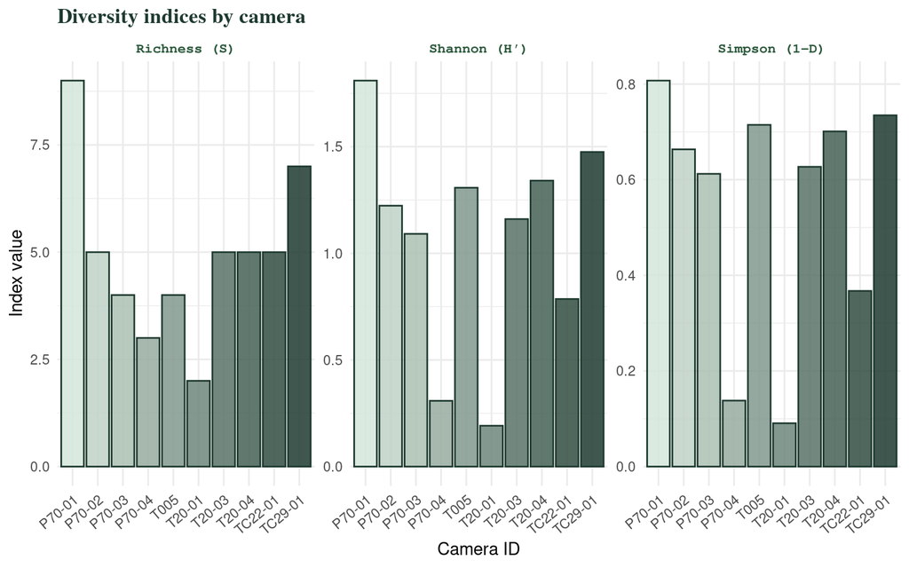

```r
div_df %>%
  pivot_longer(c(richness, shannon, simpson),
               names_to = "index", values_to = "value") %>%
  ggplot(aes(x = camera_id, y = value, fill = camera_id)) +
  geom_col(color = "#1e3a2f", alpha = 0.85, show.legend = FALSE) +
  facet_wrap(~ index, scales = "free_y",
             labeller = labeller(index = c(
               richness = "Richness (S)",
               shannon  = "Shannon (H′)",
               simpson  = "Simpson (1−D)"
             ))) +
  scale_fill_manual(
    values = colorRampPalette(c("#d4e6da", "#1e3a2f"))(nrow(div_df))
  ) +
  theme_minimal(base_size = 11) +
  theme(
    plot.title  = element_text(family = "serif", face = "bold", color = "#1e3a2f"),
    axis.text.x = element_text(angle = 40, hjust = 1),
    strip.text  = element_text(family = "mono", face = "bold", color = "#2d5a3d")
  ) +
  labs(title = "Diversity indices by camera", x = "Camera ID", y = "Index value")
```

**📌 Which diversity index to report?**

**Richness (S)** — counts species, ignores abundance; sensitive to sampling effort.  
**Shannon (H′)** — weights common and rare species equally on a log scale; the most widely reported index in ecology.  
**Simpson (1−D)** — weighted toward dominant species; less sensitive to rare taxa.  
Report all three and discuss what differences reveal about community structure. High S with low H′ indicates one highly dominant taxon with many rare ones.

### Rarefaction curves

**The problem rarefaction solves.** Camera A recorded 80 independent events and detected 6 species. Camera B recorded 12 events and detected 4 species. Is Camera A genuinely richer, or did it simply run longer and accumulate more detections by chance? Raw species counts cannot answer this — they confound ecological richness with sampling effort.

**What a rarefaction curve does.** For each camera, the `vegan` function `rarecurve()` randomly sub-samples its detection records 1, 2, 3 … n times and asks: *on average, how many species had we seen after exactly k detections?* The result is a curve of *expected* richness as a function of effort. Plotting all cameras on the same axes — with the same x-scale — makes a fair comparison possible: read off each curve at a common x-value (the **rarefaction target**, set to the smallest total across all cameras) to get effort-controlled richness.

**How to read the plot.** Each coloured line is one camera. The vertical dashed line marks the rarefaction target — the point where all cameras can be compared fairly. At that x-value, a higher curve means genuinely greater local richness, not just more deployment time.

- **Steep and still rising at the target** → the camera is under-sampled; more events would likely reveal additional species.
- **Levelling off (asymptote) before the target** → the local species pool is well-characterized; additional effort would add little.
- **Short curves that barely reach the target** → those cameras had very few total events and their richness estimates are highly uncertain.

```r
min_n <- min(rowSums(site_sp))
cat(sprintf(
  "Rarefaction target: %d detections (the minimum across %d cameras)\n",
  min_n, nrow(site_sp)
))
```

```
## Rarefaction target: 14 detections (the minimum across 10 cameras)
```

```r
cat(sprintf(
  "Cameras with more than 2× the target: %d\n",
  sum(rowSums(site_sp) > 2 * min_n)
))
```

```
## Cameras with more than 2× the target: 6
```

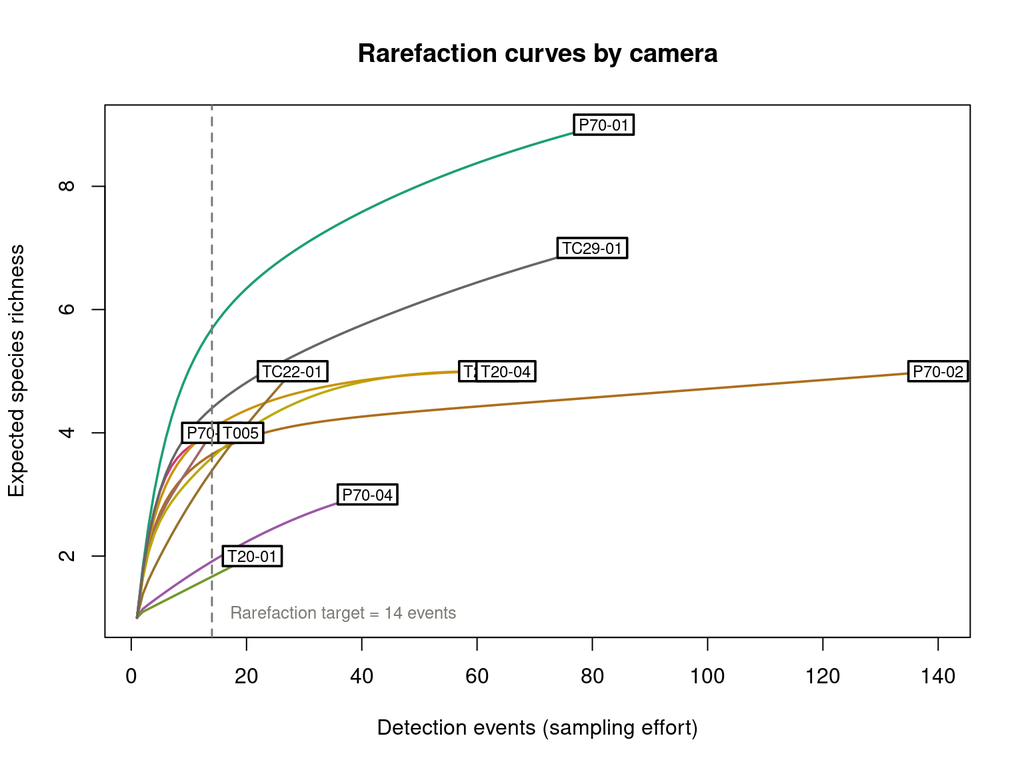

```r
# Build a color palette with one color per camera
cam_cols <- colorRampPalette(
  RColorBrewer::brewer.pal(8, "Dark2")
)(nrow(site_sp))

rarecurve(
  site_sp,
  step    = 1,
  col     = cam_cols,
  lwd     = 1.8,
  xlab    = "Detection events (sampling effort)",
  ylab    = "Expected species richness",
  main    = "Rarefaction curves by camera",
  label   = TRUE,
  cex     = 0.75
)
abline(v = min_n, lty = 2, col = "#7a7a72", lwd = 1.5)
text(min_n, par("usr")[3] + 0.3,
     paste0("Rarefaction target = ", min_n, " events"),
     adj = c(-0.08, 0), cex = 0.8, col = "#7a7a72")
```

```r
# Effort-controlled richness at the rarefaction target for each camera
rare_vals <- rarefy(site_sp, sample = min_n)

rarefied_df <- tibble(
  Camera            = names(rare_vals),
  `Raw richness`    = specnumber(site_sp),
  `Total events`    = rowSums(site_sp),
  `Rarefied S`      = round(rare_vals, 2),
  `Rank (raw)`      = rank(-specnumber(site_sp), ties.method = "min"),
  `Rank (rarefied)` = rank(-rare_vals, ties.method = "min")
) %>% arrange(`Rank (rarefied)`)

knitr::kable(
  rarefied_df,
  caption = paste0(
    "Effort-controlled species richness rarefied to ", min_n,
    " detection events per camera. ",
    "Cameras whose rarefied rank differs from their raw rank had ",
    "apparent richness inflated (or deflated) by effort differences."
  ),
  align = "lrrrrr"
)
```

Effort-controlled species richness rarefied to 14 detection events per camera. Cameras whose rarefied rank differs from their raw rank had apparent richness inflated (or deflated) by effort differences.

| Camera | Raw richness | Total events | Rarefied S | Rank (raw) | Rank (rarefied) |
| --- | --- | --- | --- | --- | --- |
| P70-01 | 9 | 82 | 5.69 | 1 | 1 |
| TC29-01 | 7 | 80 | 4.40 | 2 | 2 |
| T20-04 | 5 | 65 | 4.06 | 3 | 3 |
| P70-03 | 4 | 14 | 4.00 | 7 | 4 |
| T005 | 4 | 19 | 3.94 | 7 | 5 |
| P70-02 | 5 | 140 | 3.65 | 3 | 6 |
| T20-03 | 5 | 62 | 3.60 | 3 | 7 |
| TC22-01 | 5 | 28 | 3.39 | 3 | 8 |
| P70-04 | 3 | 41 | 1.91 | 9 | 9 |
| T20-01 | 2 | 21 | 1.67 | 10 | 10 |

**💡 Rarefied S vs. raw richness — when do they disagree?**

If a camera’s raw rank is higher than its rarefied rank, its raw species count was inflated by extra effort — it detected more species simply because it ran longer, not because its habitat is richer. The rarefied value is the fairer number to report in any cross-camera comparison. Note that rarefaction always *reduces* or maintains richness relative to the raw count — it can never add species that were not observed.

## 8. Single-Season Occupancy Modeling

### Rationale and key insight

**Which cameras does species X truly occupy?** The complication is **imperfect detection**: even when a species is present, a camera will not always fire. Treating “no detection” as “truly absent” underestimates occupancy — sometimes dramatically.

The MacKenzie et al. (2002) model simultaneously estimates:

- **ψ (psi)** — the probability a site is occupied.
- **p** — the probability of detecting the species on a given survey occasion, *given it is present*.

**⚙️ The occupancy likelihood**  
For a site with detection history [1, 0, 1]:

```
P(data) = ψ × p(1−p)p + (1−ψ) ×
0
```

For a history of all zeros [0, 0, 0]:

```
P(data) = ψ
× (1−p)³ + (1−ψ)
```

The second term captures the possibility the site was unoccupied — this is what separates a true absence from a detection failure.

### Build detection histories

```r
focal_sp    <- unique(cam_events$taxa_code)[1]
cat("Focal species:", focal_sp, "\n")
```

```
## Focal species: A_californica
```

```r
all_dates   <- sort(unique(cam_events$date))
all_cameras <- sort(unique(cam_events$camera_id))

# 1 = species detected that camera × day; 0 = not detected
det_wide <- cam_events %>%
  filter(taxa_code == focal_sp) %>%
  distinct(camera_id, date) %>%
  mutate(detected = 1) %>%
  complete(camera_id = all_cameras, date = all_dates,
           fill = list(detected = 0)) %>%
  pivot_wider(names_from = date, values_from = detected) %>%
  column_to_rownames("camera_id")

print(det_wide)
```

```
##         2026-03-09 2026-03-10 2026-03-11 2026-03-12 2026-03-13 2026-03-14
## P70-01           1          1          0          1          0          1
## P70-02           0          0          0          0          0          0
## P70-03           0          0          0          0          0          0
## P70-04           0          0          0          0          0          0
## T005             0          0          0          1          0          1
## T20-01           0          0          0          0          0          0
## T20-03           0          0          0          0          0          0
## T20-04           0          0          0          0          1          1
## TC22-01          0          0          0          0          0          0
## TC29-01          0          0          0          0          0          0
##         2026-03-15 2026-03-16 2026-03-17 2026-03-18 2026-03-19 2026-03-20
## P70-01           0          0          0          0          0          0
## P70-02           0          0          0          0          0          0
## P70-03           1          0          1          1          0          1
## P70-04           0          0          0          0          0          0
## T005             0          0          0          0          0          0
## T20-01           0          0          0          0          0          0
## T20-03           0          0          0          0          0          0
## T20-04           0          0          0          0          0          0
## TC22-01          1          0          0          0          0          0
## TC29-01          0          0          1          1          0          0
##         2026-03-21 2026-03-22 2026-03-23
## P70-01           0          0          0
## P70-02           0          1          0
## P70-03           0          0          0
## P70-04           0          0          0
## T005             0          0          0
## T20-01           0          0          0
## T20-03           0          0          0
## T20-04           0          0          0
## TC22-01          0          0          0
## TC29-01          0          0          0
```

### Fit the null occupancy model

```r
umf      <- unmarkedFrameOccu(y = as.matrix(det_wide))
fit_null <- occu(~ 1 ~ 1, data = umf)
summary(fit_null)
```

```
##
## Call:
## occu(formula = ~1 ~ 1, data = umf)
##
## Occupancy (logit-scale):
##  Estimate   SE    z P(>|z|)
##      1.32 1.06 1.25   0.212
##
## Detection (logit-scale):
##  Estimate    SE     z  P(>|z|)
##     -1.86 0.321 -5.78 7.47e-09
##
## AIC: 104.4236
## Number of sites: 10
```

```r
# Back-transform from logit scale to probability
occ_est <- backTransform(fit_null, type = "state")
det_est <- backTransform(fit_null, type = "det")

cat(sprintf(
  "\nEstimated occupancy  ψ = %.3f  (95%% CI: %.3f – %.3f)\n",
  occ_est@estimate,
  confint(occ_est)[1], confint(occ_est)[2]
))
```

```
##
## Estimated occupancy  ψ = 0.789  (95% CI: 0.320 – 0.968)
```

```r
cat(sprintf(
  "Estimated detection  p = %.3f  (95%% CI: %.3f – %.3f)\n",
  det_est@estimate,
  confint(det_est)[1], confint(det_est)[2]
))
```

```
## Estimated detection  p = 0.135  (95% CI: 0.077 – 0.227)
```

### Compare naïve vs. model-estimated occupancy

```r
naive_occ <- mean(rowSums(det_wide) > 0)

cat(sprintf(
  "Naïve occupancy (fraction of cameras with ≥1 detection): %.3f\n", naive_occ
))
```

```
## Naïve occupancy (fraction of cameras with ≥1 detection): 0.700
```

```r
cat(sprintf(
  "Model-estimated occupancy ψ:                             %.3f\n",
  occ_est@estimate
))
```

```
## Model-estimated occupancy ψ:                             0.789
```

```r
cat(sprintf(
  "Inflation due to imperfect detection:                    +%.3f\n",
  occ_est@estimate - naive_occ
))
```

```
## Inflation due to imperfect detection:                    +0.089
```

### Covariate model: does vegetation density affect occupancy?

If you have a site-level covariate (e.g., canopy cover measured at each camera), you can test whether occupancy varies with habitat quality. Replace the simulated `veg_density` below with your real covariate.

```r
# ── Replace this block with your real covariate data ────────────────────────
set.seed(7)
site_covs <- data.frame(
  veg_density = scale(runif(nrow(det_wide), 0, 100))
)
# ────────────────────────────────────────────────────────────────────────────

umf_cov <- unmarkedFrameOccu(
  y        = as.matrix(det_wide),
  siteCovs = site_covs
)

fit_cov <- occu(~ 1 ~ veg_density, data = umf_cov)
summary(fit_cov)
```

```
##
## Call:
## occu(formula = ~1 ~ veg_density, data = umf_cov)
##
## Occupancy (logit-scale):
##             Estimate   SE     z P(>|z|)
## (Intercept)    1.351 1.11 1.215   0.224
## veg_density    0.357 1.14 0.314   0.754
##
## Detection (logit-scale):
##  Estimate    SE     z  P(>|z|)
##     -1.86 0.321 -5.79 7.25e-09
##
## AIC: 106.3112
## Number of sites: 10
```

```r
# AIC comparison
aic_df <- data.frame(
  Model = c("Null  (ψ(.), p(.))",
            "Veg   (ψ(veg), p(.))"),
  AIC   = round(c(fit_null@AIC, fit_cov@AIC), 2),
  dAIC  = round(c(0, fit_cov@AIC - fit_null@AIC), 2)
)
knitr::kable(
  aic_df,
  col.names = c("Model", "AIC", "ΔAIC"),
  align     = "lcc",
  caption   = paste0(
    "AIC model comparison. The model with lower AIC is better supported. ",
    "ΔAIC > 2 is the conventional threshold for meaningful improvement. ",
    "ΔAIC < 2 means the simpler null model is preferred."
  )
)
```

AIC model comparison. The model with lower AIC is better supported. ΔAIC > 2 is the conventional threshold for meaningful improvement. ΔAIC < 2 means the simpler null model is preferred.

| Model | AIC | ΔAIC |
| --- | --- | --- |
| Null (ψ(.), p(.)) | 104.42 | 0.00 |
| Veg (ψ(veg), p(.)) | 106.31 | 1.89 |

**📌 Interpreting AIC**

The model with the **lower AIC** has better predictive support. ΔAIC > 2 is the conventional threshold for “meaningfully better”. A positive coefficient on `veg_density` in the occupancy sub-model means the species is more likely to occupy densely vegetated sites. AIC penalizes complexity — a more parameterized model must fit considerably better to justify its extra parameters.

### Predicted occupancy across the vegetation gradient

The covariate model estimated a single coefficient for `veg_density` on the **logit** (log-odds) scale. That number is hard to interpret directly — a coefficient of +0.8 does not mean “occupancy increases by 0.8.” The logit link is non-linear, so the same unit increase in vegetation density produces a larger change in ψ near 0.50 than it does near 0 or 1.

`predict()` translates the coefficient back into probability space across the full observed range of the covariate, producing the **response curve** — the most interpretable summary of the model. The code below:

1. **Creates a prediction grid** — 100 evenly spaced values of `veg_density` spanning the observed range (from the most open to the densest site).
2. **Calls `predict(type = "state")`** — `"state"` means the occupancy sub-model (ψ), as opposed to `"det"` which would give the detection sub-model (p). The function returns four columns: `Predicted` (ψ̂), `SE` (standard error on the probability scale), and `lower`/`upper` (95% confidence interval bounds).
3. **Plots the curve and ribbon** — the shaded band is the 95% CI, reflecting uncertainty in the estimated coefficient. Wide bands indicate either a small sample of cameras or weak signal in the data.

```r
# Step 1: prediction grid across the full covariate range
newdat <- data.frame(
  veg_density = seq(min(site_covs$veg_density),
                    max(site_covs$veg_density),
                    length.out = 100)
)

# Step 2: predict ψ at each grid point (back-transformed to probability scale)
pred <- predict(fit_cov, type = "state", newdata = newdat)

# Show what predict() returns — four columns
head(round(pred, 3))
```

```
##   Predicted    SE lower upper
## 1     0.722 0.284 0.140 0.976
## 2     0.724 0.278 0.146 0.976
## 3     0.726 0.273 0.152 0.975
## 4     0.728 0.268 0.158 0.974
## 5     0.730 0.263 0.164 0.974
## 6     0.731 0.259 0.171 0.973
```

[figure not shown]

```r
# Step 3: plot the response curve
pred_df <- bind_cols(newdat, pred)

# Annotate where ψ = 0.5 (the inflection point of the logistic curve)
psi50_x <- pred_df$veg_density[which.min(abs(pred_df$Predicted - 0.5))]
psi50_y <- 0.5

ggplot(pred_df, aes(x = veg_density, y = Predicted)) +
  # 95% CI ribbon
  geom_ribbon(aes(ymin = lower, ymax = upper),
              fill = "#d4e6da", alpha = 0.75) +
  # Response curve
  geom_line(color = "#1e3a2f", linewidth = 1.4) +
  # ψ = 0.5 reference lines
  geom_hline(yintercept = 0.5, linetype = "dashed",
             color = "#c8832a", linewidth = 0.7) +
  geom_vline(xintercept = psi50_x, linetype = "dashed",
             color = "#c8832a", linewidth = 0.7) +
  annotate("point", x = psi50_x, y = psi50_y,
           shape = 21, size = 3.5, fill = "#c8832a", color = "white") +
  annotate("text",
           x     = psi50_x + 0.08 * diff(range(pred_df$veg_density)),
           y     = 0.53,
           label = sprintf("ψ = 0.50
at veg = %.2f", psi50_x),
           color = "#c8832a", size = 3.2, hjust = 0, fontface = "italic") +
  # Rug: actual camera covariate values
  geom_rug(data = data.frame(veg_density = site_covs$veg_density),
           aes(x = veg_density), y = NULL,
           sides = "b", color = "#4a7c5e", alpha = 0.6, linewidth = 0.5) +
  scale_y_continuous(limits = c(0, 1),
                     labels = scales::percent_format(),
                     breaks = seq(0, 1, 0.25)) +
  labs(
    title    = paste("Predicted occupancy (ψ) for", focal_sp),
    subtitle = "Shaded band = 95% CI  |  Rug marks = actual camera locations  |  Orange lines = ψ = 0.50",
    x        = "Vegetation density (standardized z-score)",
    y        = "Estimated occupancy probability (ψ)"
  ) +
  theme_minimal(base_size = 12) +
  theme(
    plot.title    = element_text(family = "serif", face = "bold", color = "#1e3a2f"),
    plot.subtitle = element_text(size = 9, color = "#7a7a72")
  )
```

**📌 Reading the response curve — four questions to ask**

**1. Direction:** Does ψ increase or decrease with the covariate? A rising curve means the species is more likely to occupy sites with more vegetation; a falling curve means the opposite.

**2. Magnitude:** How much does ψ change across the full covariate range? If ψ only moves from 0.42 to 0.51, the effect is statistically detectable but ecologically trivial. If it moves from 0.10 to 0.85, habitat selection is strong.

**3. Uncertainty:** How wide is the shaded band? Wide CIs at the covariate extremes mean few cameras were sampled there — interpret the predicted ψ at those values with caution.

**⚠️ This example uses simulated covariate data**

The `veg_density` values above were generated with `runif()` and have no relationship to the actual cameras. The curve shape and inflection point are therefore meaningless for your real focal species. Replace the simulation block with measured field covariates — canopy cover from a densiometer, distance to water, trail-camera height class, or any site-level variable you recorded — before drawing ecological conclusions.

## 9. Summary and Discussion

Full camera-trap analysis pipeline.

| Stage | Key idea | R functions |
| --- | --- | --- |
| Import & clean | Remove ambiguous taxa; standardize columns with clean_names() | read_excel(), clean_names(), case_when() |
| Independent events | 30-minute rule collapses burst detections; prevents pseudo-replication | lag(), difftime(), cumsum() |
| Descriptive stats | Ethograms, heat maps, and camera profiles reveal community-level patterns | ggplot2: geom_col(), geom_tile() |
| Chi-square / Fisher | Tests whether behavior composition shifts between day and night | chisq.test(), fisher.test() |
| Activity overlap Δ | Kernel density Δ quantifies temporal co-occurrence on a 0–1 scale | overlapEst(), bootstrap(), bootCI() |
| Rarefaction | Controls for unequal detection effort before comparing camera richness | rarecurve(), specnumber(), diversity() |
| Occupancy model | Separates true absence from non-detection to estimate ψ and p | occu(), backTransform(), predict() |

#### 💬 Discussion Questions

1. Which taxon showed the greatest day–night behavioral shift? What ecological mechanism might explain it — predation pressure, thermoregulation, or resource availability?
2. Do species with high activity overlap (Δ > 0.75) tend to be ecologically similar (same guild) or different? What does this suggest about competitive exclusion vs. temporal partitioning?
3. Examine the rarefaction curves. Which cameras appear under-sampled (curves not levelled off)? How would you redesign the study to address this — longer deployment, more cameras, or both?
4. Compare the naïve detection rate for your focal species with the model-estimated occupancy ψ. How large is the imperfect-detection bias? Does it change any substantive conclusions about habitat use?
5. The covariate model used a simulated vegetation density variable. What real site covariates would you collect in the field, and how would you measure them consistently across cameras?

#### 🔑 Key takeaways

- **Always define independent events** before analysis. The 30-minute rule is a convention — document your threshold and justify it relative to your study organism.
- **Descriptive plots come first.** An ethogram or heat map often surfaces the most important ecological patterns before any test is run.
- **Chi-square vs. Fisher:** check expected counts with `chisq.test()$expected`; switch to `fisher.test()` automatically when any cell is below 5.
- **Activity overlap Δ is sample-size sensitive.** Use `Dhat4` when either species has fewer than 75 detections; always report a bootstrap CI alongside the point estimate.
- **Rarefaction, not raw richness,** is the correct basis for comparing cameras with unequal total events.
- **Occupancy models separate biology from observation.** Naïve detection rate systematically underestimates true occupancy when detection is imperfect — which it always is with camera traps.

### References

- MacKenzie, D. I., Nichols, J. D., Lachman, G. B., Droege, S., Royle, J. A., & Langtimm, C. A. (2002). Estimating site occupancy rates when detection probabilities are less than one. *Ecology*, 83(8), 2248–2255.
- Ridout, M. S., & Linkie, M. (2009). Estimating overlap of daily activity patterns from camera trap data. *Journal of Agricultural, Biological, and Environmental Statistics*, 14(3), 322–337.
- Fiske, I., & Chandler, R. (2011). unmarked: An R package for fitting hierarchical models of wildlife occurrence and abundance. *Journal of Statistical Software*, 43(10), 1–23.
- Oksanen, J., et al. (2022). vegan: Community Ecology Package. R package version 2.6-4.